Here we are going to show how to retrieve data from the [PokeAPI](https://pokeapi.co/) from six endpoints using functions that I have created. First we’re going to walk through the functions and then we will do a bit of data exploration.

As a general note, while it is possible to query these endpoints using numbers, I do not recommend it. For example, in the Ability endpoint, there are 327 abilities, but you can only query up to ability 267 using the index number. After that, you must use the ability name to get data about that ability. To help with this issue, I have provided **a couple lines of code** before each function that will result in a list of all available index names that you can query by or you can use the resulting list to query the entire endpoint as I have done in the data exploration.

# Required R Packages

```
## x data.table::transpose() masks purrr::transpose()
```

The following packages were used to query the API: `httr`: used to connect to the API via URL `jsonlite`: used to decode the information we got from the API into plain text `purr`: used to unlist the output from the API `data.table`: used to combine the lists into a single dataframe

The following packages were used for the data exploration: `tidyverse`: used for data manipulation and visualization

# Functions to Query PokeAPI

## Ability

The `ability` function interacts with the `ability` endpoint of the PokeAPI. The function returns a tibble with an observation for each pokemon that has the ability and what generation the ability was introduced in.

```r
# Finding a list of all available abilities
avail_ability <- GET("https://pokeapi.co/api/v2/ability/?limit=327&offset=0")
avail_ability <- rawToChar(avail_ability$content)
avail_ability <- fromJSON(avail_ability)
avail_ability <- avail_ability[["results"]][["name"]]

ability <- function(name, ...){
  ###
  # This function takes the name of the abilities supplied and returns
  # data about the Pokemon that can use this ability, what generation
  # of game the ability originated in
  ###

  url_ability <- paste0("https://pokeapi.co/api/v2/ability/", avail_ability)
  poke_bility <- lapply(url_ability, GET)
  poke_bility <- lapply(poke_bility, '[[', 'content')
  poke_bility <- lapply(poke_bility, rawToChar)
  poke_bility <- lapply(poke_bility, fromJSON)

  # Unlisting our data from the API so that we can create a tidy data frame
  abilities <- (map(poke_bility, "name"))
  ability_pokemon <- (map(map(map(poke_bility, "pokemon"), "pokemon"), "name"))
  ability_generation <- map(map(poke_bility, "generation"), "name")

  # Creating a list of tibbles
  Pokemon_Ability <- list(rep(0, length(unlist(ability_pokemon))))
    for(a in 1:length(ability_pokemon)){
      Pokemon <- unlist(ability_pokemon[a])
      Ability <- rep(abilities[[a]], length(ability_pokemon[a]))
      Generation <- rep(ability_generation[[a]], length(ability_pokemon[a]))
      Pokemon_Ability[[a]] <- as_tibble(cbind(Pokemon, Ability, Generation))
    }

  # Combining our list of tibbles into one tibble
  Pokemon_Ability <- rbindlist(Pokemon_Ability, fill = TRUE)
  return(Pokemon_Ability)
}
```

## Pokemon Type

While there are 20 possible Pokemon types, I’m not interested the information offered in the shadow or unknown Pokemon. The shadow Pokemon only offers moves that are available for that Pokemon type. The unknown Pokemon only have data about the generation of game that this Pokemon type appeared in.

For the other Pokemon types, you can query this either by numbers, 1 through 18, or with the name of the Pokemon type. The resulting tibble will only contain information about the Pokemon and the type it is. Some Pokemon do have more than one type.

```r
# Finding a list of all possible Pokemon types
avail_types <- GET("https://pokeapi.co/api/v2/type/?limit=20&offset=0")
avail_types <- rawToChar(avail_types$content)
avail_types <- fromJSON(avail_types)
avail_types <- avail_types[["results"]][["name"]]

type <- function(name, ...){
  ###
  # This function takes the Pokemon types and returns all the Pokemon
  # of that type.
  ###
  url_type <- paste0("https://pokeapi.co/api/v2/type/", c(name, ...))
  poke_type <- lapply(url_type, GET)
  poke_type <-lapply(poke_type, '[[', 'content')
  poke_type <- lapply(poke_type, rawToChar)
  poke_type <- lapply(poke_type, fromJSON)

  # Unlisting our data from the API so that we can create a tidy data frame
  types <- map(poke_type, "name")
  type_pokemon <- map(map(map(poke_type, "pokemon"), "pokemon"), "name")

  # Creating a list of tibbles
  Pokemon_Type <- list(rep(0, length(unlist(types))))
  for(a in 1:length(types)){
    Pokemon <- unlist(type_pokemon[a])
    Type <- rep(types[[a]], length(type_pokemon[a]))
    Pokemon_Type[[a]] <- as_tibble(cbind(Pokemon, Type))
  }

  # Combining our list of tibbles into one tibble
  Pokemon_Type <- rbindlist(Pokemon_Type)
  return(Pokemon_Type)
}
```

## Generation

In Pokemon, generations are generally regarded as when a ‘batch’ of new Pokemon species are released and new game mechanics are added to the video games. This function will return a tibble with observations for each Pokemon species that was introduced in that generation.

```r
# Finding a list of all available generations
avail_gen <- GET("https://pokeapi.co/api/v2/generation/")
avail_gen <- rawToChar(avail_gen$content)
avail_gen <- fromJSON(avail_gen)
avail_gen <- avail_gen[["results"]][["name"]]

generation <- function(name, ...){
  ###
  # This function takes the name of the generations supplied and returns
  # the Pokemon that was first introduced in that generation.
  ###
  url_gen <- paste0("https://pokeapi.co/api/v2/generation/", c(name, ...))
  poke_gen <- lapply(url_gen, GET)
  poke_gen <- lapply(poke_gen, '[[', 'content')
  poke_gen <- lapply(poke_gen, rawToChar)
  poke_gen <- lapply(poke_gen, fromJSON)

  # Unlisting our data from the API so that we can create a tidy data frame
  gen <- map(poke_gen, "name")
  gen_poke <- map(map(poke_gen, "pokemon_species"), "name")

  # Creating a list of tibbles
  Pokemon_Generation <- list(rep(0, length(unlist(gen_poke))))
  for(a in 1:length(gen_poke)){
    Pokemon <- unlist(gen_poke[a])
    Generation <- rep(gen[[a]], length(gen_poke[a]))
    Pokemon_Generation[[a]] <- as.tibble(cbind(Generation, Pokemon))
    }

    # Combining our list of tibbles into one tibble
  Pokemon_Generation <- rbindlist(Pokemon_Generation)
  return(Pokemon_Generation)
}

# This works
# Generation23 <- generation("generation-ii", "generation-iii")
```

## Habitat

```r
# Finding a list of all available habitats
avail_habitat <- GET("https://pokeapi.co/api/v2/pokemon-habitat/?limit=20&offset=0")
avail_habitat <- rawToChar(avail_habitat$content)
avail_habitat <- fromJSON(avail_habitat)
avail_habitat <- avail_habitat[["results"]][["name"]]

habitat <- function(name, ...){
  ###
  # This function takes the name of the habitat and returns what Pokemon that
  # can be found in that habitat
  ###

  url_habitat <- paste0("https://pokeapi.co/api/v2/pokemon-habitat/", c(name, ...))
  poke_habitat <- lapply(url_habitat, GET)
  poke_habitat <-lapply(poke_habitat, '[[', 'content')
  poke_habitat <- lapply(poke_habitat, rawToChar)
  poke_habitat <- lapply(poke_habitat, fromJSON)

  # Unlisting our data from the API so that we can create a tidy data frame
  habitat <- map(poke_habitat, "name")
  habitat_poke <- map(map(poke_habitat, "pokemon_species"), "name")

  # Creating a list of tibbles
  Pokemon_Habitat <- list(rep(0, length(unlist(habitat_poke))))
  for(a in 1:length(habitat_poke)){
    Pokemon <- unlist(habitat_poke[a])
    Habitat <- rep(habitat[[a]], length(habitat_poke[a]))
    Pokemon_Habitat[[a]] <- as.tibble(cbind(Habitat, Pokemon))
  }

  # Combining our list of tibbles into one tibble
  Pokemon_Habitat <- rbindlist(Pokemon_Habitat)
  return(Pokemon_Habitat)

}
```

## Berries

Berries are in-game items that can heal status effects, restore health points, or have some other effect on Pokemon the berry is fed to. This function will take the name of the berry and return how long it takes the berry to grow on a bush and the maximum number of berries on a bush.

```r
# Finding a list of all available berries
avail_berry <- GET("https://pokeapi.co/api/v2/berry?offset=0&limit=200")
avail_berry <- rawToChar(avail_berry$content)
avail_berry <- fromJSON(avail_berry)
avail_berry <- avail_berry[["results"]][["name"]]

berry <- function(name, ...){
  ###
  # This function takes the name of the berry and returns data about
  # the germination period of berries and the number of fruit the bush bears
  ###
  url_berry <- paste0("https://pokeapi.co/api/v2/berry/", c(name, ...))
  poke_berry <- lapply(url_berry, GET)
  poke_berry <- lapply(poke_berry, '[[', 'content')
  poke_berry <- lapply(poke_berry, rawToChar)
  poke_berry <- lapply(poke_berry, fromJSON)

  # Unlisting our data from the API so that we can create a tidy data frame
  berries <- unlist(map(poke_berry, "name"))
  growth_time <- unlist(map(poke_berry, "growth_time"))
  max_harvest <- unlist(map(poke_berry, "max_harvest"))

  # Combining tibbles into one tibble
  Pokemon_Berry <- as_tibble(cbind(berries, growth_time, max_harvest))
  return(Pokemon_Berry)
}

# It works
# berry("cheri", "chesto")
```

## Pokemon Base Stats

Here we get the base stats of all available Pokemon, as well as what generation the pokemon belongs to. There are six available stats in the Pokemon endpoint - hp, attack, defense, special attack, special defense, and speed.

```r
# Finding a list of all possible Pokemon
avail_pokemon <- GET("https://pokeapi.co/api/v2/pokemon/?limit=1200&offset=0")
avail_pokemon <- rawToChar(avail_pokemon$content)
avail_pokemon <- fromJSON(avail_pokemon)
avail_pokemon <- avail_pokemon[["results"]][["name"]]


poke_stats <- function(name, ...){
  ###
  # This function takes the Pokemon names and returns all the Pokemon
  # stats for those species.
  ###
  url <- paste0("https://pokeapi.co/api/v2/pokemon/",c(name, ...))
  pokedex <- lapply(X = url, FUN = GET)
  pokedex<-lapply(pokedex, '[[', 'content')
  pokedex <- lapply(pokedex, rawToChar)
  pokedex <- lapply(pokedex, fromJSON)

  # Unlisting our data from the API so that we can create a tidy data frame
  pokemon_stat <- map(pokedex, "name")
  base_stat <- map(map(pokedex, "stats"), "base_stat")

  # Initializing the variables whose values I want
  Pokemon <- rep(0, length(pokemon_stat))
  hp <- rep(0, length(pokemon_stat))
  attack  <- rep(0, length(pokemon_stat))
  defense <- rep(0, length(pokemon_stat))
  sp_attack <- rep(0, length(pokemon_stat))
  sp_defense <- rep(0, length(pokemon_stat))
  speed <- rep(0, length(pokemon_stat))

  # Creating a tibble of the Pokemon and their stats
  for(p in 1:length(pokemon_stat)){
    Pokemon[p] <- pokemon_stat[[p]]
    hp[p] <- as.numeric(base_stat[[p]][1])
    attack[p]  <- base_stat[[p]][2]
    defense[p] <- base_stat[[p]][3]
    sp_attack[p] <- base_stat[[p]][4]
    sp_defense[p] <- base_stat[[p]][5]
    speed[p] <- base_stat[[p]][6]
  }
  Pokemon_Stats <- as_tibble(cbind(Pokemon, hp, attack, defense, sp_attack, sp_defense, speed))

# The stats are printed as character values so we just want to change these to numeric
  for(s in 2:7){
      Pokemon_Stats[[s]] <- as.numeric(Pokemon_Stats[[s]])
  }

  return(Pokemon_Stats)
}
```

# Exploratory Data Analysis

## Generating Data Sets

I only want to analyze the first [898 pokemon] (https://www.wargamer.com/pokemon-trading-card-game/how-many-pokemon-are-there). The PokeAPI is structured so that the first 898 Pokemon are the strict unique species, while the rest are types of the species that may have a different regional form or are evolved in a special way that grants them special base stats. I only wanted to analyze the base stats from ‘normal’ pokemon, because in-game a trainer can manipulate the stats of their pokemon through berries and other in-game items.

```r
# Creating Data Frames
Pokemon_Habitat <- habitat(avail_habitat)
Pokemon_Stats <- poke_stats(avail_pokemon)
Pokemon_Ability <- ability(avail_ability)
Pokemon_Generation <- generation(avail_gen)

# Only querying the first 898 unique pokemon
Pokemon_Stats <- Pokemon_Stats[1:898, ]

# There are no Pokemon unknown or shadow types, so we only need to
# query the first 18 types
Pokemon_Types <- type(1:18)

# Creating a new variable that is the sum of the other statistics
Pokemon_Stats <- Pokemon_Stats %>% mutate(total_stats = hp + attack + defense +
                    sp_attack + sp_defense + speed)
Pokemon_Stats <- merge(Pokemon_Stats, Pokemon_Generation, by = "Pokemon")

sort(Pokemon_Types$Pokemon)
```

```
##    [1] "abomasnow"                  "abomasnow"
##    [3] "abomasnow-mega"             "abomasnow-mega"
##    [5] "abra"                       "absol"
##    [7] "absol-mega"                 "accelgor"
##    [9] "aegislash-blade"            "aegislash-blade"
##   [11] "aegislash-shield"           "aegislash-shield"
##   [13] "aerodactyl"                 "aerodactyl"
##   [15] "aerodactyl-mega"            "aerodactyl-mega"
##   [17] "aggron"                     "aggron"
##   [19] "aggron-mega"                "aipom"
##   [21] "alakazam"                   "alakazam-mega"
##   [23] "alcremie"                   "alcremie-gmax"
##   [25] "alomomola"                  "altaria"
##   [27] "altaria"                    "altaria-mega"
##   [29] "altaria-mega"               "amaura"
```

[output cut: 843 more lines]

```r
Pokemon_Type1 <- filter(Pokemon_Types, duplicated(Pokemon_Types$Pokemon) == FALSE)
Pokemon_Type2 <- filter(Pokemon_Types, duplicated(Pokemon_Types$Pokemon) == TRUE)

Pokemon_Type1 <- rename(Pokemon_Type1, Type1 = Type)
Pokemon_Type2 <- rename(Pokemon_Type2, Type2 = Type)

# I just want a left join because Pokemon Stats contains the "mega"
# pokemon
Pokemon_Type_Stats <- merge(Pokemon_Stats, Pokemon_Type1,
                            by = "Pokemon", all.x = TRUE)
Pokemon_Type_Stats <- merge(Pokemon_Type_Stats, Pokemon_Type2,
                            by = "Pokemon", all.x = TRUE)
Pokemon_Type_Stats <- Pokemon_Type_Stats %>% mutate(
  Type2 = if_else(is.na(Type2) == TRUE, Type1, Type2))
```

### Pokemon Attribute Exploration

```r
Habitat_Gen <- merge(Pokemon_Habitat, Pokemon_Generation, by = "Pokemon")
table(Habitat_Gen$Habitat, Habitat_Gen$Generation)
```

```
##
##                 generation-i generation-ii generation-iii
##   cave                     8             7             14
##   forest                  21            21             29
##   grassland               35            25             20
##   mountain                18            12             15
##   rare                     5             3              2
##   rough-terrain            8             5             14
##   sea                     15             8             17
##   urban                   22            10              5
##   waters-edge             19             9             19
```

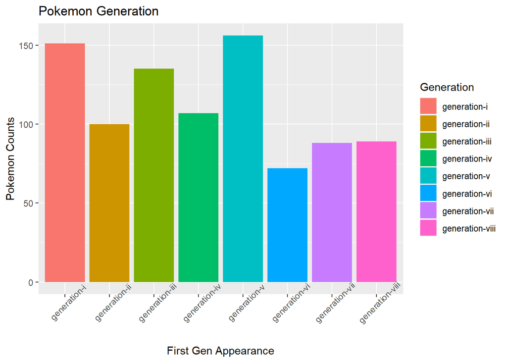

```r
Pokemon_Gen_Plot <- ggplot(data = Pokemon_Generation, aes(x = Generation)) +
  geom_bar(aes(fill = Generation)) +
  labs(title = "Pokemon Generation", x = "First Gen Appearance",
       y = "Pokemon Counts") +
  theme(axis.text.x=element_text(angle=45))
Pokemon_Gen_Plot
```

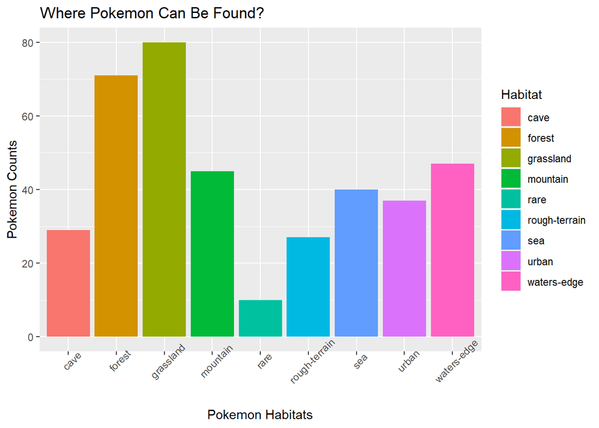

```r
Pokemon_Hab_Plot <- ggplot(data = Pokemon_Habitat, aes(x = Habitat)) +
  geom_bar(aes(fill = Habitat)) +
  labs(title = "Where Pokemon Can Be Found?", x = "Pokemon Habitats",
       y = "Pokemon Counts") +
  theme(axis.text.x=element_text(angle=45))
Pokemon_Hab_Plot
```

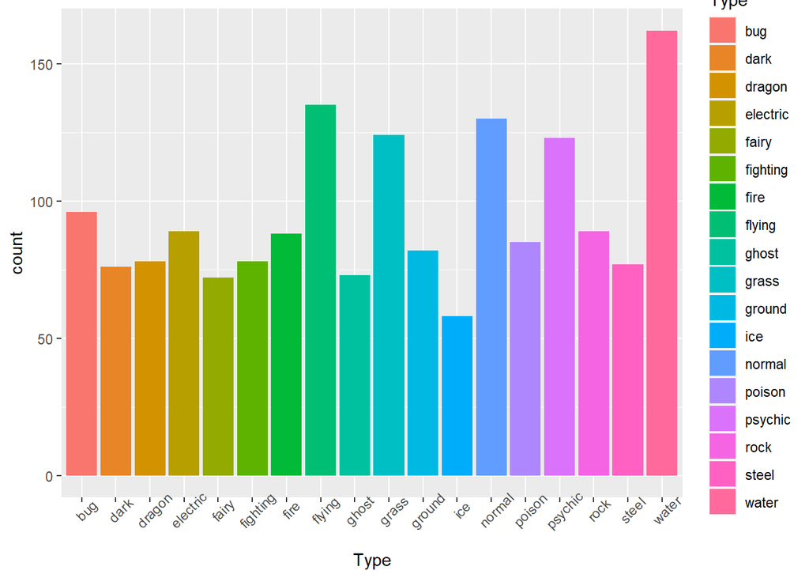

```r
Pokemon_Type_Plot <- ggplot(data = Pokemon_Types, aes(x = Type)) +
  geom_bar(aes(fill = Type)) +
  theme(axis.text.x=element_text(angle=45))
Pokemon_Type_Plot
```

```r
table(Pokemon_Type_Stats$Type1, Pokemon_Type_Stats$Type2)
```

```
##
##            bug dark dragon electric fairy fighting fire flying ghost grass
##   bug       19    0      0        4     2        0    4      0     1     5
##   dark       0   11      0        0     3        0    0      0     0     0
##   dragon     0    4     13        0     0        0    0      0     0     0
##   electric   0    1      2       32     2        0    0      0     0     0
##   fairy      0    0      0        0    18        0    0      0     0     0
##   fighting   3    3      2        0     0       27    6      1     1     3
##   fire       0    3      2        0     0        0   32      0     0     0
##   flying    13    5      6        2     2        0    5      2     2     6
##   ghost      0    2      3        1     0        0    4      0    13     4
##   grass      0    4      3        0     5        0    0      0     0    42
##   ground     1    3      6        1     0        0    2      0     5     1
##   ice        0    2      1        0     0        0    0      0     0     0
##   normal     0    1      1        2     4        2    2     26     0     2
##   poison    12    3      3        1     0        0    2      0     3    14
##   psychic    0    2      2        0     7        0    0      0     0     0
##   rock       5    1      2        0     2        0    3      0     0     2
##   steel      0    2      2        4     3        0    1      0     0     3
##   water      0    4      3        2     4        0    0      0     0     3
##
##            ground ice normal poison psychic rock steel water
##   bug           0   2      0      0       2    0     5     5
##   dark          0   0      0      0       0    0     0     0
##   dragon        0   0      0      0       0    0     0     0
##   electric      0   1      0      0       0    0     0     0
##   fairy         0   0      0      0       0    0     0     0
##   fighting      0   1      0      2       3    1     2     1
##   fire          0   0      0      0       2    0     0     1
##   flying        2   2      0      3       6    3     3     8
##   ghost         0   1      0      0       2    0     2     2
##   grass         0   2      0      0       4    0     0     0
##   ground       17   3      0      0       2    9     2     9
##   ice           0  13      0      0       0    0     0     0
##   normal        1   0     69      0       2    0     0     1
##   poison        2   0      0     16       0    1     0     6
##   psychic       0   3      0      0      35    0     0     0
##   rock          0   2      0      0       2   12     7    11
##   steel         0   0      0      0       7    0     9     1
##   water         0   7      0      0       5    0     0    65
```

### Is there a power creep between generations of pokemon?

```r
Summary_hp <- Pokemon_Stats %>% group_by(Generation) %>%
  summarise(min_hp = min(hp), avg_hp = round(mean(hp)), max_hp = max(hp))

Summary_attack <- Pokemon_Stats %>% group_by(Generation) %>%
  summarise(min_attack = min(attack), avg_attack = round(mean(attack)),
            max_attack = max(attack))

Summary_defense <- Pokemon_Stats %>% group_by(Generation) %>%
  summarise(min_defense = min(defense), avg_defense = round(mean(defense)),
            max_defense = max(defense))

Summary_sp_attack <- Pokemon_Stats %>% group_by(Generation) %>%
  summarise(min_sp_attack = min(sp_attack), avg_sp_attack = round(mean(sp_attack)),
            max_sp_attack = max(sp_attack))

Summary_sp_defense <- Pokemon_Stats %>% group_by(Generation) %>%
  summarise(min_sp_defense = min(sp_defense),
            avg_sp_defense = round(mean(sp_defense)),
            max_sp_defense = max(sp_defense))

Summary_speed <- Pokemon_Stats %>% group_by(Generation) %>%
  summarise(min_speed = min(speed), avg_speed = round(mean(speed)),
            max_speed = max(speed))

#Summary_total_stats <- Pokemon_Stats %>% group_by(Generation) %>%
#  summarise(min_total_stats = min(total_stats),
#            avg_total_stats = round(mean(total_stats)),
#            max_total_stats = max(total_stats))

Summary_hp
```

```
## # A tibble: 8 x 4
##   Generation      min_hp avg_hp max_hp
##   <chr>            <dbl>  <dbl>  <dbl>
## 1 generation-i        10     64    250
## 2 generation-ii       20     71    255
## 3 generation-iii       1     66    170
## 4 generation-iv       20     72    150
## 5 generation-v        30     70    165
## 6 generation-vi       38     69    126
## 7 generation-vii      25     72    223
## 8 generation-viii     25     70    200
```

```r
Summary_attack
```

```
## # A tibble: 8 x 4
##   Generation      min_attack avg_attack max_attack
##   <chr>                <dbl>      <dbl>      <dbl>
## 1 generation-i             5         73        134
## 2 generation-ii           10         68        134
## 3 generation-iii          15         73        160
## 4 generation-iv            5         80        165
## 5 generation-v            25         80        150
## 6 generation-vi           22         73        131
## 7 generation-vii          29         86        181
## 8 generation-viii         20         78        145
```

```r
Summary_defense
```

```
## # A tibble: 8 x 4
##   Generation      min_defense avg_defense max_defense
##   <chr>                 <dbl>       <dbl>       <dbl>
## 1 generation-i              5          68         180
## 2 generation-ii            10          70         230
## 3 generation-iii           20          69         200
## 4 generation-iv             5          74         168
## 5 generation-v             32          71         145
## 6 generation-vi            33          74         184
## 7 generation-vii           30          79         211
## 8 generation-viii          20          71         145
```

```r
Summary_sp_attack
```

```
## # A tibble: 8 x 4
##   Generation      min_sp_attack avg_sp_attack max_sp_attack
##   <chr>                   <dbl>         <dbl>         <dbl>
## 1 generation-i               15            67           154
## 2 generation-ii              10            64           130
## 3 generation-iii             10            67           150
## 4 generation-iv              10            73           150
## 5 generation-v               15            68           150
## 6 generation-vi              27            73           150
## 7 generation-vii             20            76           173
## 8 generation-viii            20            71           145
```

```r
Summary_sp_defense
```

```
## # A tibble: 8 x 4
##   Generation      min_sp_defense avg_sp_defense max_sp_defense
##   <chr>                    <dbl>          <dbl>          <dbl>
## 1 generation-i                20             66            125
## 2 generation-ii               20             72            230
## 3 generation-iii              20             67            200
## 4 generation-iv               30             74            150
## 5 generation-v                25             67            135
## 6 generation-vi               25             74            154
## 7 generation-vii              30             75            142
## 8 generation-viii             20             68            130
```

```r
Summary_speed
```

```
## # A tibble: 8 x 4
##   Generation      min_speed avg_speed max_speed
##   <chr>               <dbl>     <dbl>     <dbl>
## 1 generation-i           15        69       150
## 2 generation-ii           5        61       130
## 3 generation-iii         10        61       160
## 4 generation-iv           5        69       125
## 5 generation-v           10        65       145
## 6 generation-vi          23        65       126
## 7 generation-vii          5        64       151
## 8 generation-viii        10        66       200
```

```r
#Summary_total_stats
```

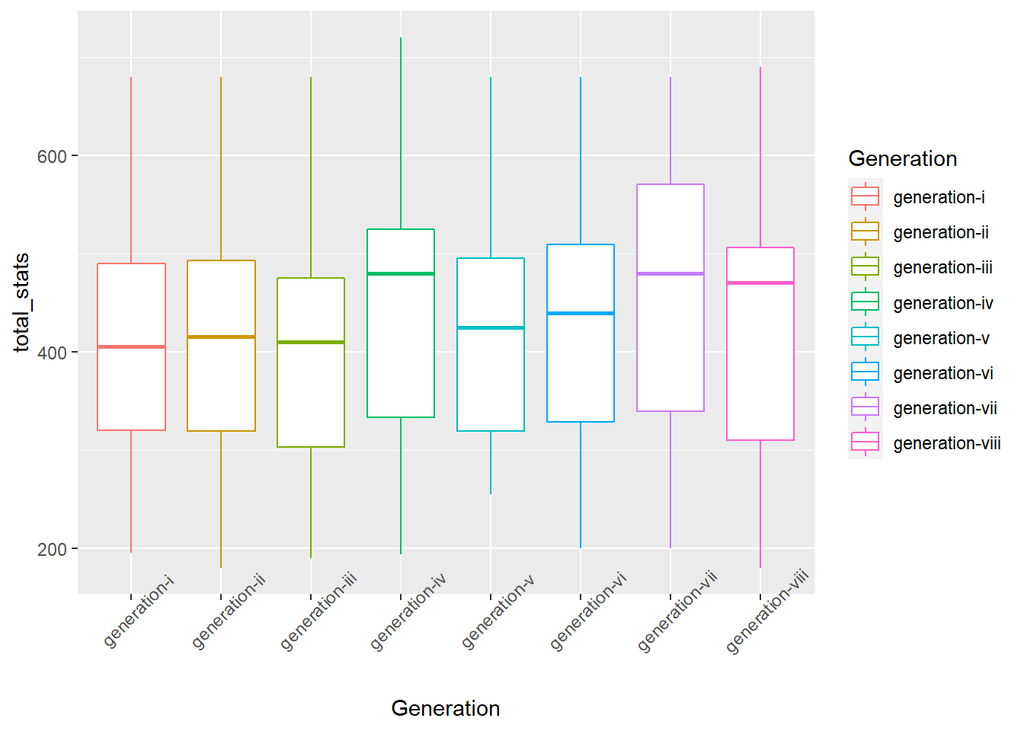

```r
Stat_Boxplot <- ggplot(data = Pokemon_Stats)

Stat_Boxplot +
  geom_boxplot(mapping = aes(x = total_stats, y = Generation, color = Generation)) +
  coord_flip() +
  theme(axis.text.x=element_text(angle=45))
```

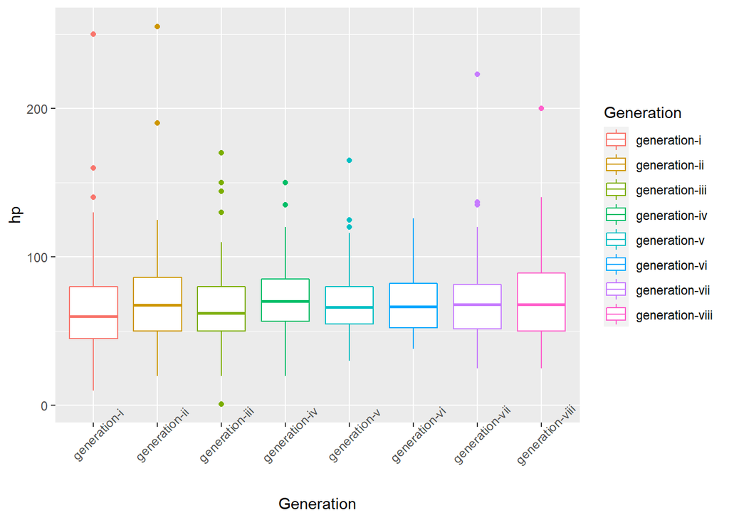

```r
Stat_Boxplot +
  geom_boxplot(mapping = aes(x = hp, y = Generation, color = Generation)) +
  coord_flip() +
  theme(axis.text.x=element_text(angle=45))
```

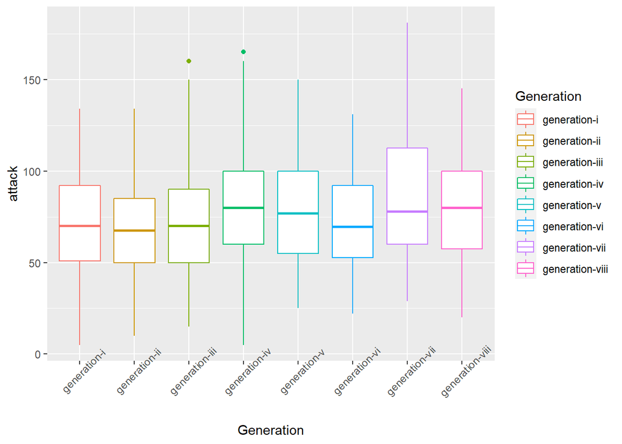

```r
Stat_Boxplot +
  geom_boxplot(mapping = aes(x = attack, y = Generation, color = Generation)) +
  coord_flip() +
  theme(axis.text.x=element_text(angle=45))
```

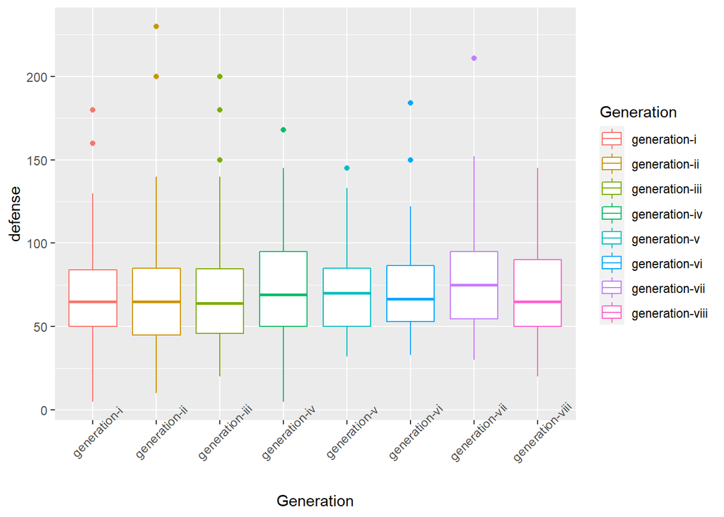

```r
Stat_Boxplot +
  geom_boxplot(mapping = aes(x = defense, y = Generation, color = Generation)) +
  coord_flip() +
  theme(axis.text.x=element_text(angle=45))
```

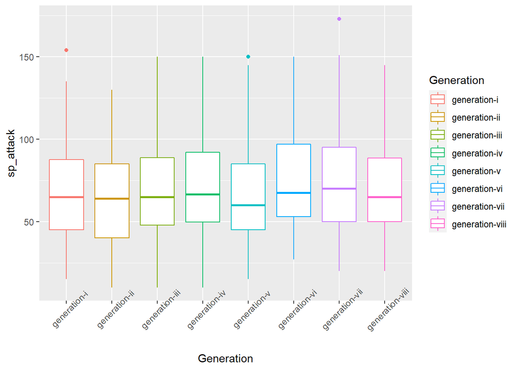

```r
Stat_Boxplot +
  geom_boxplot(mapping = aes(x = sp_attack, y = Generation, color = Generation)) +
  coord_flip() +
  theme(axis.text.x=element_text(angle=45))
```

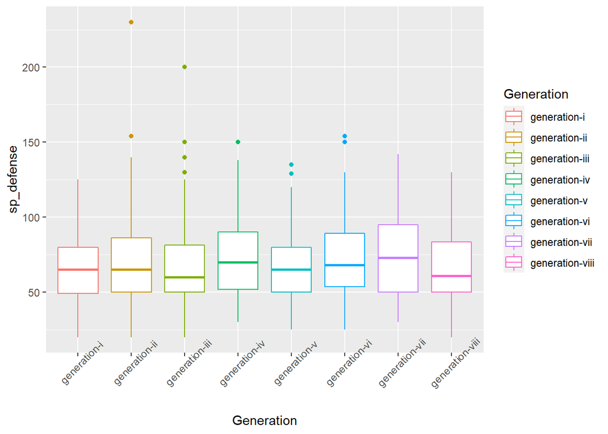

```r
Stat_Boxplot +
  geom_boxplot(mapping = aes(x = sp_defense, y = Generation, color = Generation)) +
  coord_flip() +
  theme(axis.text.x=element_text(angle=45))
```

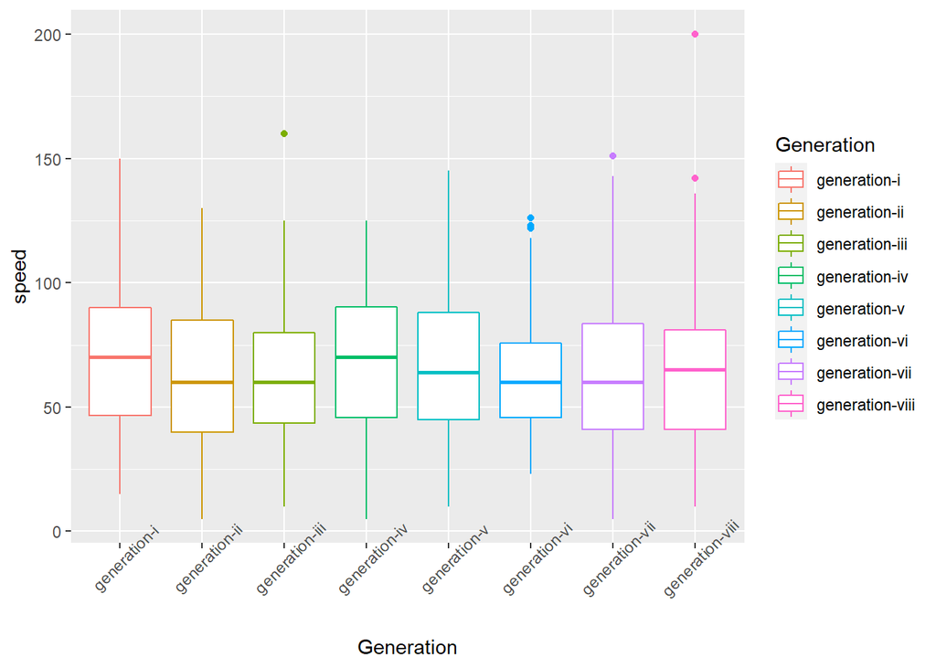

```r
Stat_Boxplot +
  geom_boxplot(mapping = aes(x = speed, y = Generation, color = Generation)) +
  coord_flip() +
  theme(axis.text.x=element_text(angle=45))
```

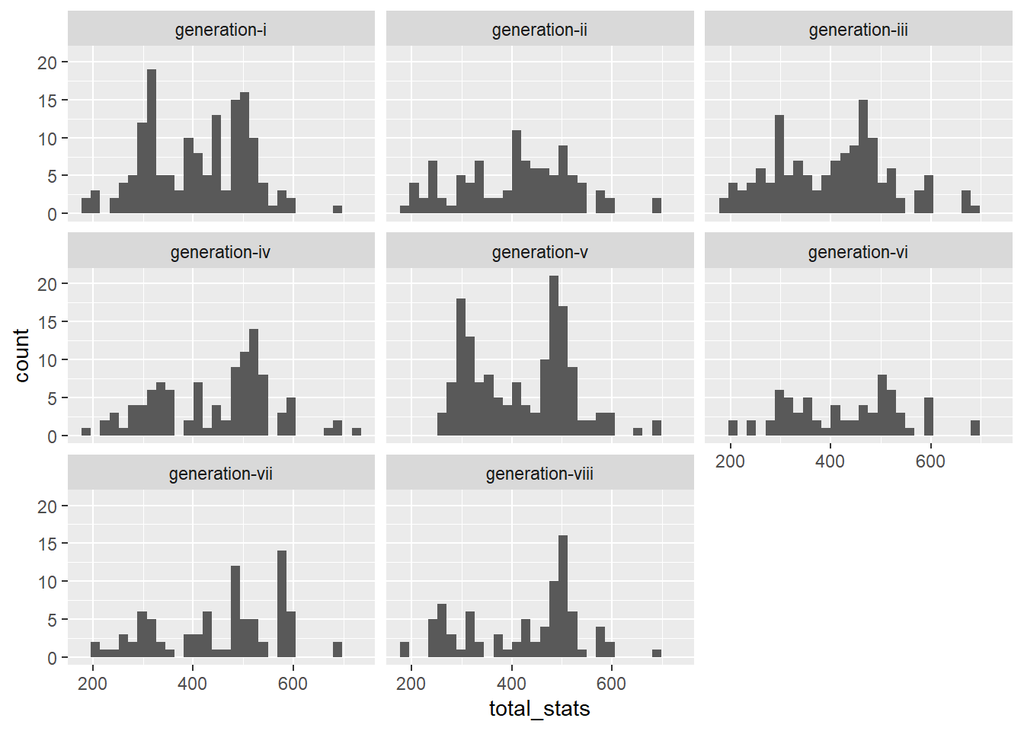

```r
Stat_Hist <- ggplot(data = Pokemon_Stats)+
  geom_histogram(mapping = aes(x = total_stats)) +
  facet_wrap(vars(Generation))

Stat_Hist
```

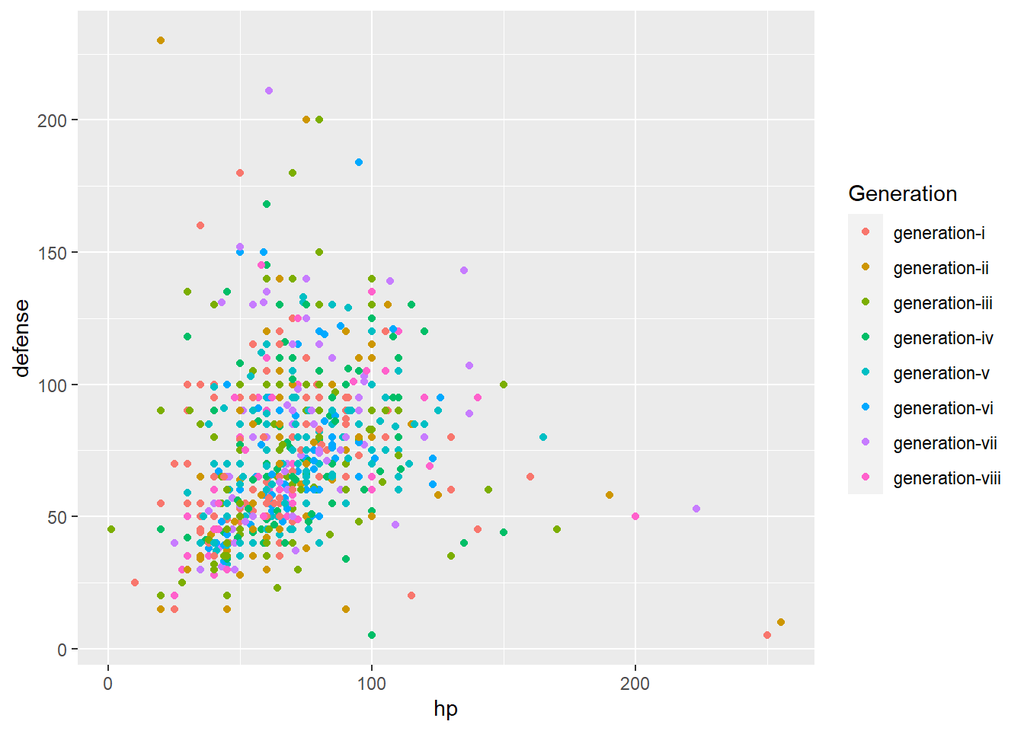

```r
HP_Defense <- ggplot(data = Pokemon_Stats, aes(x = hp, y = defense)) +
  geom_point(aes(color = Generation))
HP_Defense
```

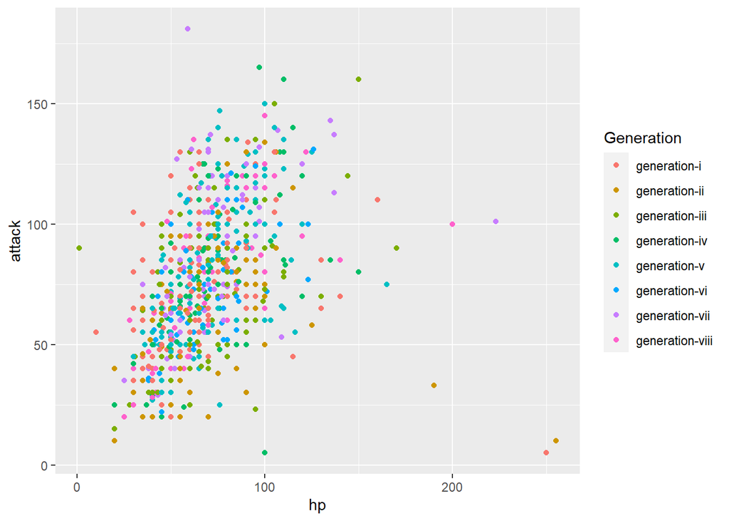

```r
HP_Attack <- ggplot(data = Pokemon_Stats, aes(x = hp, y = attack)) +
  geom_point(aes(color = Generation))
HP_Attack
```

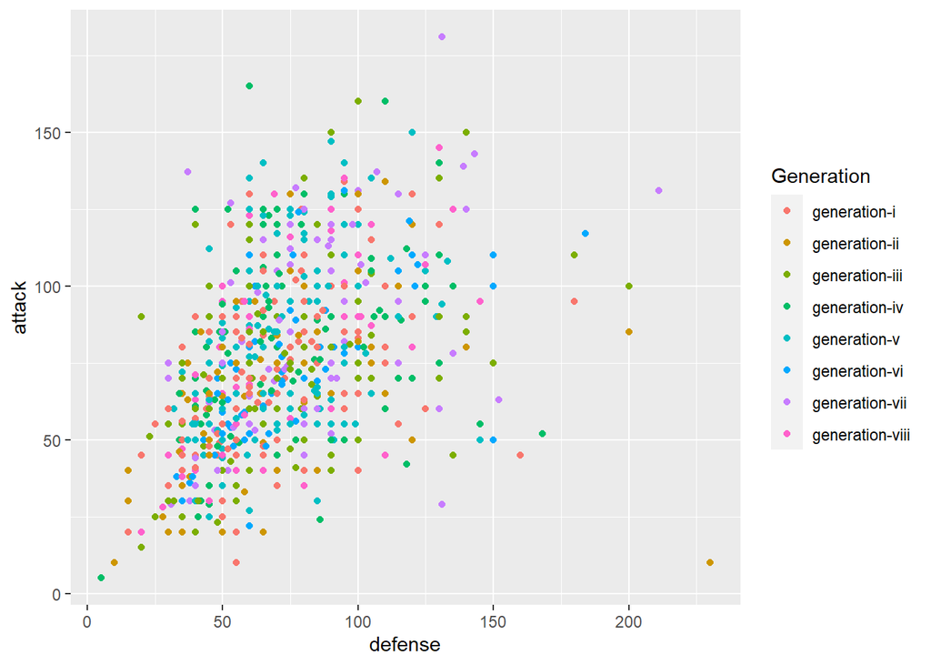

```r
Defense_Attack <- ggplot(data = Pokemon_Stats, aes(x = defense, y = attack)) +
  geom_point(aes(color = Generation))
Defense_Attack
```

```r
Stats_Generation <- lm(total_stats ~ Generation, data = Pokemon_Stats)
Stats_Generation
```

```
##
## Call:
## lm(formula = total_stats ~ Generation, data = Pokemon_Stats)
##
## Coefficients:
##               (Intercept)    Generationgeneration-ii
##                  407.6424                    -0.4624
##  Generationgeneration-iii    Generationgeneration-iv
##                   -5.3812                    34.5884
##    Generationgeneration-v    Generationgeneration-vi
##                   12.0757                    20.5194
##  Generationgeneration-vii  Generationgeneration-viii
##                   44.0926                    15.7673
```